# Parcial 2: Ciencia de datos en el Sector Salud

Juan José Rudas Granados

27/10/2021

## 2 Examen Parcial- Ciencias de Datos

### *Introdución*

El cáncer de mama (CM) es uno de los cánceres más comunes entre las mujeres en todo el mundo, y representa la mayoría de los casos nuevos de cáncer y las muertes relacionadas con el cáncer según las estadísticas mundiales, lo que lo convierte en un problema de salud pública importante en la sociedad actual. El diagnóstico precoz de CM puede mejorar el pronóstico y mejorar tasa de supervivencia significativamente, ya que puede promover el tratamiento oportuno a los pacientes que lo padecen. Una clasificación más precisa de los tumores benignos puede evitar que los pacientes se sometan a tratamientos innecesarios. Por tanto, el diagnóstico correcto de CM y la clasificación de los pacientes en grupos malignos o benignos es objeto de mucha investigación. Teniendo en cuenta, el desarrollo de la inteligencia artificial y la aplicación de algoritmos de aprendizaje automático (ML), la clasificación de patrones de CM y el modelado pronóstico ha permitdo la deteccion temprana cancer en sus etapas iniciales.

Los métodos de clasificación y extracción de datos son una forma eficaz de clasificar eventos adversos y son técnicas ampliamente en el diagnóstico y análisis para tomar decisiones en el sector clínico.

### Pregunta de Investigación:

**¿Cuáles son las variables más relevantes del data set que permiten predecir si una mujer tiene o no cancer de mama?**

# Desarrollo de parcial

### Paso 1: Carga de librerias y dataset (cancer_Breast)

### librerias

```r
library(caret)
library(dplyr)
```

```r
library(ggplot2)

library(tidyverse)
```

### Importación de data.set

```r
cancer <- read_delim("breastCancer_parcial.csv",
                     delim = ";", escape_double = FALSE, trim_ws = TRUE)
cancer <- data.frame(cancer)
```

### Paso2:Exploración de datos

```r
dim(cancer)
```

```
## [1] 500  32
```

```r
head(cancer, 5)
```

```
##         id diagnosis radius_mean texture_mean perimeter_mean area_mean
## 1   842302         M       17.99        10.38         122.80    1001.0
## 2   842517         M       20.57        17.77         132.90    1326.0
## 3 84300903         M       19.69        21.25         130.00    1203.0
## 4 84348301         M       11.42        20.38          77.58     386.1
## 5 84358402         M       20.29        14.34         135.10    1297.0
##   smoothness_mean compactness_mean concavity_mean concave.points_mean
## 1         0.11840          0.27760         0.3001             0.14710
## 2         0.08474          0.07864         0.0869             0.07017
## 3         0.10960          0.15990         0.1974             0.12790
## 4         0.14250          0.28390         0.2414             0.10520
## 5         0.10030          0.13280         0.1980             0.10430
##   symmetry_mean fractal_dimension_mean radius_se texture_se perimeter_se
## 1        0.2419                0.07871    1.0950     0.9053        8.589
## 2        0.1812                0.05667    0.5435     0.7339        3.398
```

[output cut: 27 more lines]

#### Responde las siguientes preguntas:

#### 1-Conversión de la variable diagnosis a variable categorica

```r
cancer2 <- cancer %>% mutate(diagnosis = factor(diagnosis))

table(cancer2$diagnosis)
```

```
##
##   B   M
## 305 195
```

#### 2-Cuantas pacientes y predictores tiene el dataset?

```r
dim(cancer)
```

```
## [1] 500  32
```

Respuesta: El dataset cuenta con 500 pacientes y predictores

#### 3- Resumen de datos

#### Tabla de numero de NA por variable

```r
NAs <- apply(X = is.na (cancer),MARGIN = 2,FUN = sum)
```

Transformación a Data frame para comodidad

```r
CantidadNA <- data.frame(NAs)
```

#### Tabla de numeros nulos por variable

```r
Nulos <-apply(X = cancer == 0 ,MARGIN =2,FUN=sum)

table(Nulos)
```

```
## Nulos
## 0 8
## 3 1
```

Transformación a Data frame para comodidad

```r
CantidadNulos <- data.frame(Nulos)
```

#### 4- Grafica NAvsNulls

[figure not shown]

```r
#Cantidad de Nulos
Cnulos <- sum(is.na(CantidadNulos$Nulos))

# Cantidad de NAs
CNas <- sum(CantidadNA$NAs)

#### Crear data e impresión de grafica
NullNa <- data.frame(
  Tipo=c("Null","Na") ,
  Cantidad=c(Cnulos,CNas)
)
TNullvsNA <- ggplot(NullNa, aes(x=Tipo,y =Cantidad)) +
  geom_bar(stat = "identity",color="black",fill=rgb(0.1,0.4,0.5,0.7))+
  ggtitle("Null vs Na")

TNullvsNA
```

#### 5-Asignación de diagnosis para maligno y benigno a M y B

```r
cancer3 <- cancer %>% mutate_if(is.character,str_replace,"M","Maligno")
cancer3 <- cancer3 %>% mutate_if(is.character,str_replace,"B","Benigno")
table(cancer3$diagnosis)
```

```
##
## Benigno Maligno
##     305     195
```

#### Conversión a factor

```r
cancer3 <- cancer3 %>% mutate(diagnosis = factor(diagnosis))
```

#### 6- Porcentaje de pacientes concancer B y M

```r
tablaBM <- data.frame(table(cancer3$diagnosis))

colnames(tablaBM) <- c('Enfermedad','Numero de pacientes')

tablaBM$Porcentaje <- tablaBM$`Numero de pacientes` / sum(tablaBM$`Numero de pacientes`) * 100

tablaBM
```

```
##   Enfermedad Numero de pacientes Porcentaje
## 1    Benigno                 305         61
## 2    Maligno                 195         39
```

Respuesta: 61% de pacientes con efermedad benigna y 39% con enfermedad maligna

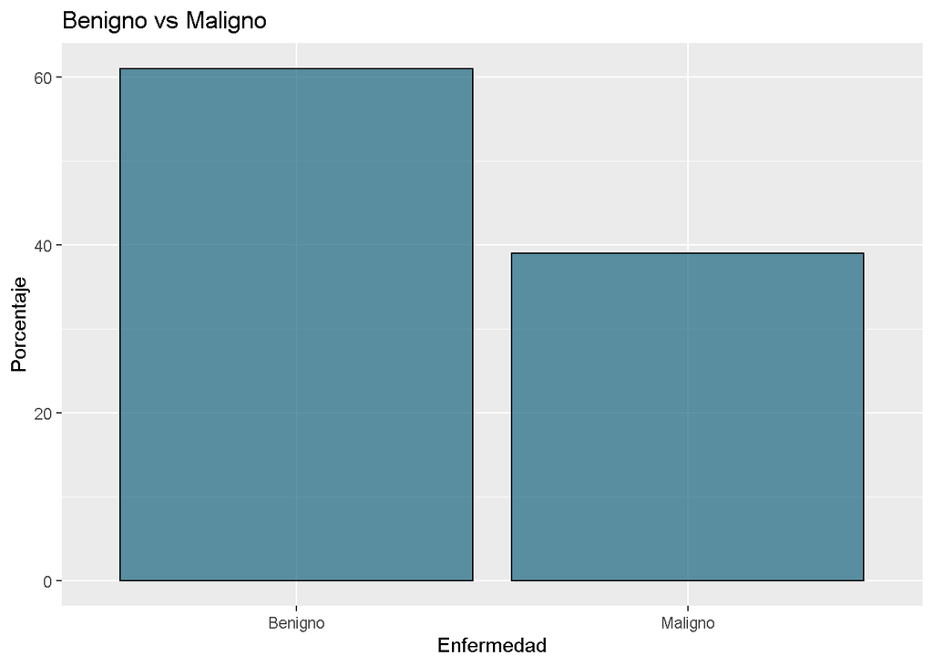

```r
TBvM <- ggplot(tablaBM, aes(x=Enfermedad,y =Porcentaje)) +
  geom_bar(stat = "identity",color="black",fill=rgb(0.1,0.4,0.5,0.7))+
  ggtitle("Benigno vs Maligno")

TBvM
```

### PASO 3

#### 7- Para realizar la imputación de valores, se selecciona el metodo de calcular la media de cada variable y asignar el valor a los datos faltantes.

```r
columnas_numericas <- which(sapply(cancer3, is.numeric))
cancermean <- rep(NA, ncol(cancer))
cancermean[columnas_numericas] <- colMeans(cancer3[, columnas_numericas], na.rm = TRUE)

for (x in columnas_numericas) {
  cancer3[is.na(cancer3[,x]), x] <- cancermean[x]
}
```

#### 8- Identificación y eliminación de valores atipicos

#### Eliminación de valores atipicos en boxplot

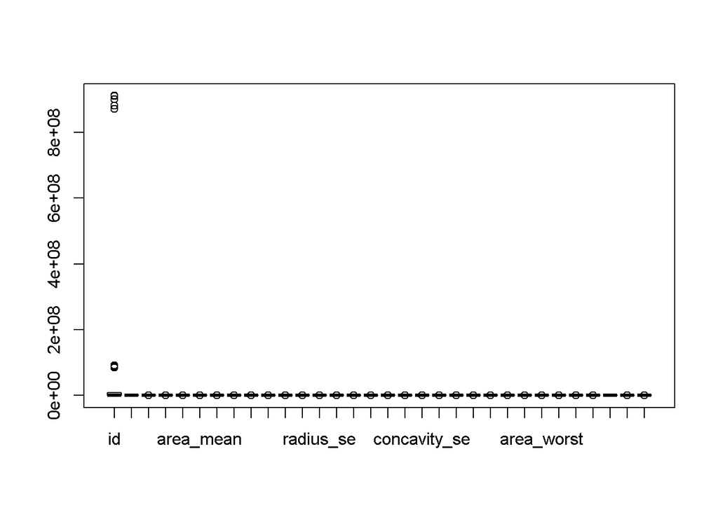

```r
boxplot(cancer3)
```

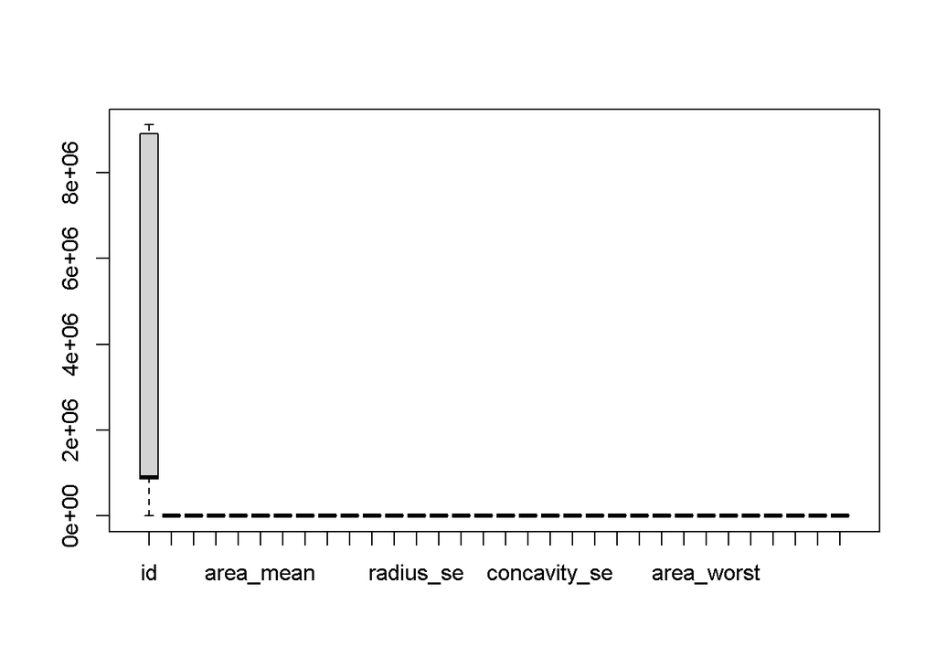

```r
EVA <- boxplot(cancer3,outline = FALSE)
```

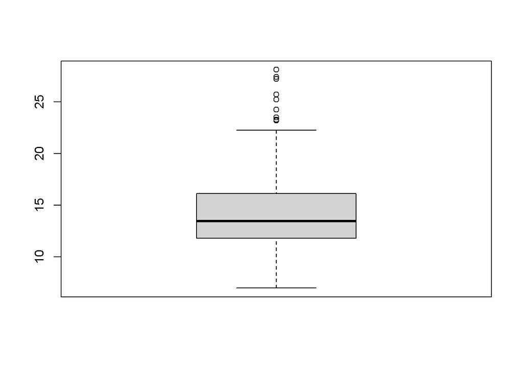

```r
#Comprobación con variable radius_mean
boxplot(cancer3$radius_mean)
```

```r
boxplot.stats(cancer3$radius_mean)
```

```
## $stats
## [1]  6.981 11.805 13.445 16.120 22.270
##
## $n
## [1] 500
##
## $conf
## [1] 13.1401 13.7499
##
## $out
##  [1] 25.22 24.25 23.27 27.22 23.29 28.11 23.21 23.51 25.73 27.42
```

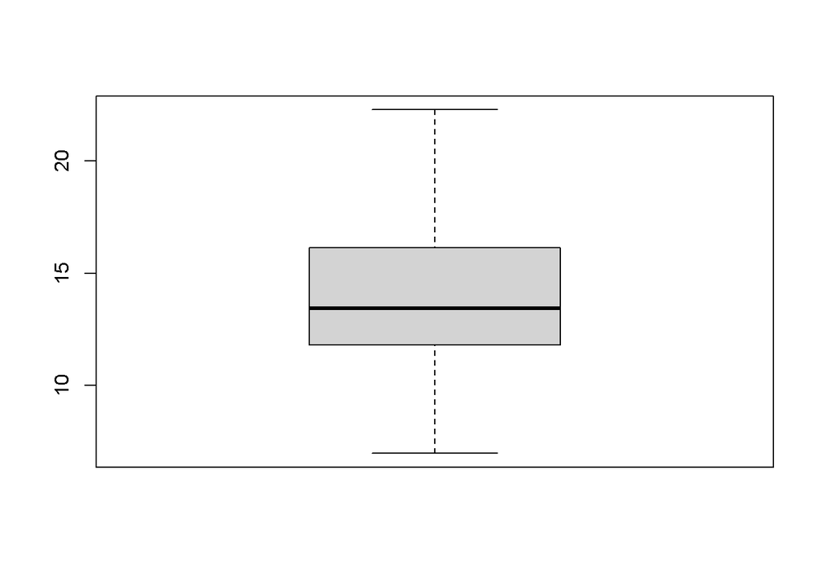

```r
EVAradius <- boxplot(cancer3$radius_mean,outline = FALSE)
```

```r
#Eliminación de valores atipicos en data.frame
```

```r
outliersReplace <- function(data, lowLimit, highLimit){
  data[data < lowLimit] <- mean(data)
  data[data > highLimit] <- mean(data)
  data     #devolvemos el dato
}

cancer4 <- cancer3
```

```r
cancer4 <- cancer3
boxplot.stats(cancer3$radius_mean)
```

```
## $stats
## [1]  6.981 11.805 13.445 16.120 22.270
##
## $n
## [1] 500
##
## $conf
## [1] 13.1401 13.7499
##
## $out
##  [1] 25.22 24.25 23.27 27.22 23.29 28.11 23.21 23.51 25.73 27.42
```

```r
cancer4$radius_mean <- outliersReplace(cancer3$radius_mean, 1, 22)


boxplot.stats(cancer3$texture_mean)
```

```
## $stats
## [1]  9.710 16.070 18.700 21.565 29.290
##
## $n
## [1] 500
##
## $conf
## [1] 18.31172 19.08828
##
## $out
## [1] 32.47 33.81 39.28 33.56 31.12 29.81 30.72 29.97
```

```r
cancer4$texture_mean <- outliersReplace(cancer3$texture_mean, 1, 29)


boxplot.stats(cancer3$perimeter_mean)
```

```
## $stats
## [1]  43.790  76.120  87.035 106.250 147.300
##
## $n
## [1] 500
##
## $conf
## [1] 84.90602 89.16398
##
## $out
##  [1] 171.5 152.8 166.2 152.1 182.1 158.9 188.5 153.5 155.1 174.2 186.9
```

```r
cancer4$perimeter_mean <- outliersReplace(cancer3$perimeter_mean, 43, 151)


boxplot.stats(cancer3$area_mean)
```

```
## $stats
## [1]  143.50  431.95  558.65  801.55 1335.00
##
## $n
## [1] 500
##
## $conf
## [1] 532.5342 584.7658
##
## $out
##  [1] 1404 1878 1509 1761 1686 2250 1685 2499 1670 1364 1419 1491 1747 2010 1546
## [16] 1482 1386 1407 1384 2501
```

```r
cancer4$area_mean <- outliersReplace(cancer3$area_mean, 40, 1350)


boxplot.stats(cancer3$smoothness_mean)
```

```
## $stats
## [1] 0.062510 0.086210 0.095955 0.105000 0.132600
##
## $n
## [1] 500
##
## $conf
## [1] 0.0946273 0.0972827
##
## $out
## [1] 0.1425 0.1398 0.1447 0.1335
```

```r
cancer4$smoothness_mean <- outliersReplace(cancer3$smoothness_mean, 0, 0.132)


boxplot.stats(cancer3$compactness_mean)
```

```
## $stats
## [1] 0.019380 0.063735 0.092350 0.130400 0.229300
##
## $n
## [1] 500
##
## $conf
## [1] 0.08763947 0.09706053
##
## $out
##  [1] 0.2776 0.2839 0.2396 0.2458 0.3454 0.2665 0.2768 0.2867 0.2832 0.2413
## [11] 0.3114 0.2364 0.2363 0.2576
```

```r
cancer4$compactness_mean <- outliersReplace(cancer3$compactness_mean, 0, 0.229)


boxplot.stats(cancer3$concavity_mean)
```

```
## $stats
## [1] 0.00000 0.02932 0.06583 0.13220 0.28100
##
## $n
## [1] 500
##
## $conf
## [1] 0.05856053 0.07309947
##
## $out
##  [1] 0.3001 0.3130 0.3754 0.3339 0.4264 0.3003 0.4268 0.4108 0.2871 0.3523
## [11] 0.3201 0.3176 0.2914 0.3368 0.3189 0.3635
```

```r
cancer4$concavity_mean <- outliersReplace(cancer3$concavity_mean, 0, 0.29)


boxplot.stats(cancer3$concave.points_mean)
```

```
## $stats
## [1] 0.000000 0.020335 0.034840 0.074490 0.150400
##
## $n
## [1] 500
##
## $conf
## [1] 0.03101342 0.03866658
##
## $out
##  [1] 0.1604 0.1845 0.1823 0.2012 0.1878 0.1620 0.1595 0.1913 0.1562 0.1689
```

```r
cancer4$concave.points_mean <- outliersReplace(cancer3$concave.points_mean, 0, 0.15)


boxplot.stats(cancer3$symmetry_mean)
```

```
## $stats
## [1] 0.11670 0.16205 0.17995 0.19535 0.24190
##
## $n
## [1] 500
##
## $conf
## [1] 0.177597 0.182303
##
## $out
##  [1] 0.2597 0.2521 0.3040 0.2743 0.2906 0.2556 0.2655 0.2678 0.2540 0.2548
## [11] 0.2495 0.2595 0.2569 0.2459 0.2538
```

```r
cancer4$symmetry_mean <- outliersReplace(cancer3$symmetry_mean, 0, 0.241)


boxplot.stats(cancer3$fractal_dimension_mean)
```

```
## $stats
## [1] 0.049960 0.057585 0.061285 0.065675 0.077690
##
## $n
## [1] 500
##
## $conf
## [1] 0.06071336 0.06185664
##
## $out
##  [1] 0.07871 0.09744 0.08243 0.07800 0.07799 0.08046 0.08980 0.08142 0.07818
## [10] 0.07782 0.07839 0.08261 0.09296 0.08116 0.08104 0.08743 0.08450 0.07950
```

```r
cancer4$fractal_dimension_mean<- outliersReplace(cancer$fractal_dimension_mean, 0, 0.0776)


boxplot.stats(cancer3$radius_se)
```

```
## $stats
## [1] 0.11150 0.23410 0.32805 0.49545 0.88110
##
## $n
## [1] 500
##
## $conf
## [1] 0.3095831 0.3465169
##
## $out
##  [1] 1.0950 0.9555 1.0460 1.2140 0.9811 0.9806 0.9317 0.8973 1.2150 1.5090
## [11] 1.2960 1.0000 1.0880 2.8730 0.9553 1.0580 1.0040 1.2920 1.1720 1.1670
## [21] 1.1110 1.0720 1.0090 0.9948 0.9761 1.2070 1.0080 1.3700 0.9291 2.5470
## [31] 0.9289
```

```r
cancer4$radius_se<- outliersReplace(cancer$radius_se, 0, 0.88110)


boxplot.stats(cancer3$texture_se)
```

```
## $stats
## [1] 0.3602 0.8257 1.0880 1.4585 2.3420
##
## $n
## [1] 500
##
## $conf
## [1] 1.043287 1.132713
##
## $out
##  [1] 3.568 2.910 3.120 2.508 2.664 4.885 2.612 2.454 2.777 2.509 2.836 2.878
## [13] 2.542 2.426 2.643 3.647
```

```r
cancer4$texture_se<- outliersReplace(cancer$texture_se, 0, 2.34)


boxplot.stats(cancer3$perimeter_se)
```

```
## $stats
## [1] 0.7570 1.6450 2.3275 3.4145 6.0510
##
## $n
## [1] 500
##
## $conf
## [1] 2.202468 2.452532
##
## $out
##  [1]  8.589 11.070  7.276  8.077  8.830  6.311  8.649  7.382 10.050  9.807
## [11]  8.419  6.971  7.337  7.029 21.980  6.487  7.247  6.372  7.158 10.120
## [21]  6.146  7.749  8.867  7.237  7.804  6.076  6.462  7.222  7.128  7.733
## [31]  7.561  9.424 18.650
```

```r
cancer4$perimeter_se<- outliersReplace(cancer$perimeter_se, 0, 6)


boxplot.stats(cancer3$area_se)
```

```
## $stats
## [1]  6.802 18.030 24.970 46.875 89.740
##
## $n
## [1] 500
##
## $conf
## [1] 22.93182 27.00818
##
## $out
##  [1] 153.40  94.03  94.44 116.20 112.40  93.99 102.60 111.40  93.54 105.00
## [11] 106.00 104.90  98.81 102.50  96.05 134.80 116.40 120.00 170.00  90.47
## [21] 233.00 101.90  93.91 119.30  97.07  97.85 122.30 128.70 111.70 525.60
## [31] 124.40 109.90 155.80 137.90  92.81 106.40 138.50  90.94 199.70 156.80
## [41] 133.00 130.80 164.10 153.10 103.60 224.10 130.20 176.50 103.90 115.20
## [51] 542.20 104.90  95.77
```

```r
cancer4$area_se<- outliersReplace(cancer$area_se, 0, 89.7)


boxplot.stats(cancer3$smoothness_se)
```

```
## $stats
## [1] 0.0017130 0.0051455 0.0062545 0.0079750 0.0119300
##
## $n
## [1] 500
##
## $conf
## [1] 0.006054568 0.006454432
##
## $out
##  [1] 0.01721 0.01340 0.01385 0.01291 0.01835 0.02333 0.01243 0.01496 0.01286
## [10] 0.01439 0.01380 0.01345 0.03113 0.01604 0.01236 0.01380 0.01418 0.01574
## [19] 0.02075 0.01289 0.01736 0.01582 0.01474 0.01307 0.01459
```

```r
cancer4$smoothness_se<- outliersReplace(cancer$smoothness_se, 0, 0.011)


boxplot.stats(cancer3$compactness_se)
```

```
## $stats
## [1] 0.003012 0.013015 0.020350 0.032485 0.060630
##
## $n
## [1] 500
##
## $conf
## [1] 0.01897425 0.02172575
##
## $out
##  [1] 0.07458 0.07217 0.08297 0.10060 0.07056 0.08606 0.09368 0.06835 0.08668
## [10] 0.07446 0.06760 0.09806 0.09586 0.08808 0.13540 0.08555 0.08262 0.10640
## [19] 0.06590 0.06559 0.07643 0.06669 0.06213 0.06657 0.07025 0.07471
```

```r
cancer4$compactness_se<- outliersReplace(cancer$compactness_se, 0.0030, 0.013)


boxplot.stats(cancer3$concavity_se)
```

```
## $stats
## [1] 0.000000 0.015100 0.025985 0.042420 0.082320
##
## $n
## [1] 500
##
## $conf
## [1] 0.02405458 0.02791542
##
## $out
##  [1] 0.08890 0.09723 0.30380 0.10910 0.10400 0.14350 0.09263 0.12780 0.39600
## [10] 0.11970 0.11660 0.08958 0.14380 0.08880 0.09518 0.09960 0.10270 0.09953
## [19] 0.15350 0.09472 0.11140
```

```r
cancer4$concavity_se<- outliersReplace(cancer$concavity_se, 0, 0.0083)


boxplot.stats(cancer3$concave.points_se)
```

```
## $stats
## [1] 0.000000 0.007631 0.010905 0.014620 0.024800
##
## $n
## [1] 500
##
## $conf
## [1] 0.01041116 0.01139884
##
## $out
##  [1] 0.04090 0.02638 0.03322 0.02593 0.02801 0.05279 0.02794 0.02765 0.03927
## [10] 0.03024 0.03487 0.02771 0.02527 0.02536 0.02919 0.03441 0.02598 0.02721
```

```r
cancer4$concave.points_se<- outliersReplace(cancer$concave.points_se, 0, 0.024)


boxplot.stats(cancer3$symmetry_se)
```

```
## $stats
## [1] 0.007882 0.015025 0.018795 0.023535 0.035460
##
## $n
## [1] 500
##
## $conf
## [1] 0.01819369 0.01939631
##
## $out
##  [1] 0.05963 0.04484 0.03672 0.05333 0.04183 0.04192 0.04197 0.07895 0.05014
## [10] 0.04547 0.05168 0.05628 0.03880 0.05113 0.03799 0.04783 0.04499 0.04077
## [19] 0.06146 0.04022 0.04243 0.03756 0.03675 0.05543 0.03710
```

```r
cancer4$symmetry_se<- outliersReplace(cancer$symmetry_se, 0, 0.01)


boxplot.stats(cancer3$fractal_dimension_se)
```

```
## $stats
## [1] 0.0008948 0.0022050 0.0031195 0.0044695 0.0077310
##
## $n
## [1] 500
##
## $conf
## [1] 0.002959491 0.003279509
##
## $out
##  [1] 0.009208 0.010080 0.012840 0.008093 0.009559 0.021930 0.010390 0.012980
##  [9] 0.009875 0.009423 0.009368 0.011780 0.029840 0.017920 0.011720 0.012560
## [17] 0.008675 0.008660 0.008015 0.022860 0.007877 0.012200 0.012330 0.008925
## [25] 0.008133 0.011300 0.009627
```

```r
cancer4$fractal_dimension_se<- outliersReplace(cancer$fractal_dimension_se, 0, 0.0077)


boxplot.stats(cancer3$radius_worst)
```

```
## $stats
## [1]  7.930 12.840 14.845 18.500 26.730
##
## $n
## [1] 500
##
## $conf
## [1] 14.44507 15.24493
##
## $out
##  [1]  0.00  0.00 29.17  0.00  0.00  0.00  0.00  0.00  0.00  0.00  0.00  0.00
## [13]  0.00 28.40  0.00  0.00  0.00  0.00  0.00 28.01  0.00 28.11 27.90 31.01
## [25] 32.49 28.19 30.67 33.13 30.75 27.66 36.04  0.00  0.00
```

```r
cancer4$radius_worst<- outliersReplace(cancer$radius_worst, 7, 26.7)


boxplot.stats(cancer3$texture_worst)
```

```
## $stats
## [1] 12.02000 21.04500 25.39472 29.25500 40.68000
##
## $n
## [1] 500
##
## $conf
## [1] 24.81461 25.97484
##
## $out
##  [1]  0.00  0.00 41.85 45.41 41.78 44.87 49.54 47.16  0.00 41.61
```

```r
cancer4$texture_worst<- outliersReplace(cancer$texture_worst, 12, 40.6)


boxplot.stats(cancer3$perimeter_worst)
```

```
## $stats
## [1]  50.41  83.64  97.18 125.25 186.80
##
## $n
## [1] 500
##
## $conf
## [1]  94.23985 100.12015
##
## $out
##  [1]   0.0   0.0   0.0   0.0   0.0   0.0   0.0   0.0   0.0   0.0   0.0 211.7
## [13]   0.0   0.0 206.8   0.0   0.0   0.0   0.0   0.0 220.8 188.5 206.0 214.0
## [25] 195.9 202.4 229.3 199.5 195.0 251.2
```

```r
cancer4$perimeter_worst<- outliersReplace(cancer$perimeter_worst, 50.4, 125.2)


boxplot.stats(cancer3$area_worst)
```

```
## $stats
## [1]    0.00  521.60  691.75 1151.50 2089.00
##
## $n
## [1] 500
##
## $conf
## [1] 647.2414 736.2586
##
## $out
##  [1] 2398 2615 2215 2145 2562 2360 2232 2403 3216 2499 2477 2944 3432 2384 2906
## [16] 3234 3143 2227 4254
```

```r
cancer4$area_worst<- outliersReplace(cancer$area_worst, 0, 2089)


boxplot.stats(cancer3$smoothness_worst)
```

```
## $stats
## [1] 0.08125 0.11640 0.13130 0.14600 0.18830
##
## $n
## [1] 500
##
## $conf
## [1] 0.1292085 0.1333915
##
## $out
## [1] 0.20980 0.19090 0.07117 0.22260 0.21840
```

```r
cancer4$smoothness_worst<- outliersReplace(cancer$smoothness_worst, 0, 0.188)


boxplot.stats(cancer3$compactness_worst)
```

```
## $stats
## [1] 0.02729 0.14585 0.21685 0.34245 0.62470
##
## $n
## [1] 500
##
## $conf
## [1] 0.2029583 0.2307417
##
## $out
##  [1] 0.6656 0.8663 1.0580 0.7725 0.6577 0.6643 0.6590 0.7444 0.7394 0.6997
## [11] 0.7584 0.9327 0.9379 0.7090
```

```r
cancer4$compactness_worst<- outliersReplace(cancer$compactness_worst, 0, 0.188)


boxplot.stats(cancer3$concavity_worst)
```

```
## $stats
## [1] 0.00000 0.11445 0.23140 0.39000 0.78920
##
## $n
## [1] 500
##
## $conf
## [1] 0.2119297 0.2508703
##
## $out
## [1] 1.1050 1.2520 0.9608 0.8216 0.8488 0.8489 0.8402 0.9034 0.9019
```

```r
cancer4$concavity_worst<- outliersReplace(cancer$concavity_worst, 0, 0.789)


boxplot.stats(cancer3$concave.points_worst)
```

```
## $stats
## [1] 0.000000 0.063255 0.100650 0.167000 0.291000
##
## $n
## [1] 500
##
## $conf
## [1] 0.0933194 0.1079806
##
## $out
## numeric(0)
```

```r
cancer4$concave.points_worst<- outliersReplace(cancer$concave.points_worst, 0, 0.789)


boxplot.stats(cancer3$symmetry_worst)
```

```
## $stats
## [1] 0.1565 0.2516 0.2831 0.3201 0.4228
##
## $n
## [1] 500
##
## $conf
## [1] 0.2782598 0.2879402
##
## $out
##  [1] 0.4601 0.6638 0.4378 0.4366 0.4667 0.4264 0.4761 0.4270 0.4863 0.4670
## [11] 0.5440 0.4882 0.5774 0.5166 0.4753 0.4432 0.4724 0.5558 0.4245 0.4824
## [21] 0.4677
```

```r
cancer4$symmetry_worst<- outliersReplace(cancer$symmetry_worst, 0.15, 0.422)


boxplot.stats(cancer3$fractal_dimension_worst)
```

```
## $stats
## [1] 0.05504 0.07105 0.07996 0.09186 0.12240
##
## $n
## [1] 500
##
## $conf
## [1] 0.07848957 0.08143043
##
## $out
##  [1] 0.1730 0.1244 0.2075 0.1431 0.1341 0.1275 0.1402 0.1233 0.1339 0.1405
## [11] 0.1252 0.1486 0.1259 0.1284 0.1446 0.1243 0.0000 0.1297 0.0000 0.1297
## [21] 0.0000 0.0000 0.1403 0.1249
```

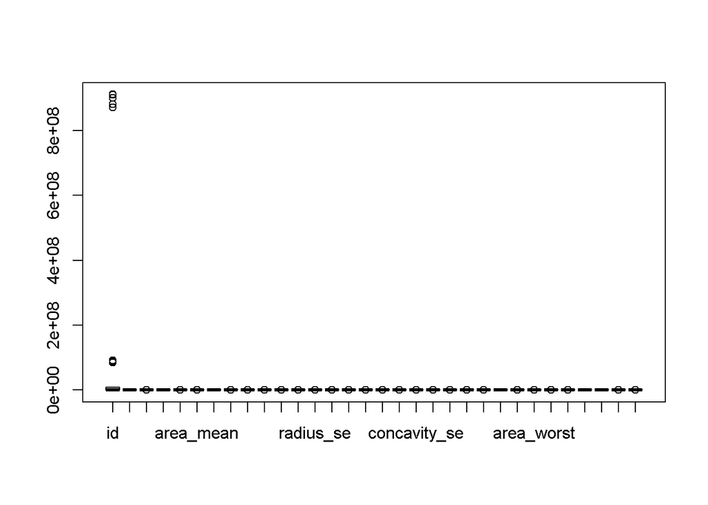

```r
cancer4$fractal_dimension_worst<- outliersReplace(cancer$fractal_dimension_worst, 0.05, 0.12)


#Eliminación de valores nulos
columnas_numericas2 <- which(sapply(cancer4, is.numeric))
cancermean2 <- rep(NA, ncol(cancer4))
cancermean2[columnas_numericas2] <- colMeans(cancer4[, columnas_numericas2], na.rm = TRUE)

for (x in columnas_numericas2) {
  cancer4[is.na(cancer4[,x]), x] <- cancermean2[x]
}

boxplot(cancer4)
```

#### 9- resumen de datos con Summary

```r
summary(cancer4)
```

```
##        id              diagnosis    radius_mean      texture_mean
##  Min.   :     8670   Benigno:305   Min.   : 6.981   Min.   : 9.71
##  1st Qu.:   866704   Maligno:195   1st Qu.:11.807   1st Qu.:16.07
##  Median :   901432                 Median :13.445   Median :18.70
##  Mean   : 32630491                 Mean   :13.977   Mean   :18.85
##  3rd Qu.:  8910808                 3rd Qu.:15.670   3rd Qu.:21.41
##  Max.   :911320502                 Max.   :21.750   Max.   :28.77
##  perimeter_mean     area_mean      smoothness_mean   compactness_mean
##  Min.   : 43.79   Min.   : 143.5   Min.   :0.06251   Min.   :0.01938
##  1st Qu.: 76.13   1st Qu.: 432.0   1st Qu.:0.08629   1st Qu.:0.06374
##  Median : 87.03   Median : 558.6   Median :0.09595   Median :0.09235
##  Mean   : 91.08   Mean   : 622.8   Mean   :0.09553   Mean   :0.09909
##  3rd Qu.:102.83   3rd Qu.: 729.2   3rd Qu.:0.10440   3rd Qu.:0.12745
##  Max.   :147.30   Max.   :1335.0   Max.   :0.12910   Max.   :0.22840
##  concavity_mean    concave.points_mean symmetry_mean    fractal_dimension_mean
##  Min.   :0.00000   Min.   :0.00000     Min.   :0.1167   Min.   :0.04996
##  1st Qu.:0.02940   1st Qu.:0.02035     1st Qu.:0.1621   1st Qu.:0.05761
##  Median :0.06583   Median :0.03484     Median :0.1799   Median :0.06128
##  Mean   :0.08270   Mean   :0.04654     Mean   :0.1788   Mean   :0.06165
##  3rd Qu.:0.11915   3rd Qu.:0.06791     3rd Qu.:0.1932   3rd Qu.:0.06470
##  Max.   :0.28710   Max.   :0.14960     Max.   :0.2403   Max.   :0.07692
##    radius_se        texture_se      perimeter_se      area_se
##  Min.   :0.1115   Min.   :0.3602   Min.   :0.757   Min.   : 6.802
##  1st Qu.:0.2343   1st Qu.:0.8261   1st Qu.:1.647   1st Qu.:18.035
##  Median :0.3281   Median :1.0880   Median :2.328   Median :24.970
##  Mean   :0.3587   Mean   :1.1377   Mean   :2.489   Mean   :29.428
##  3rd Qu.:0.4275   3rd Qu.:1.3893   3rd Qu.:3.003   3rd Qu.:33.010
##  Max.   :0.8811   Max.   :2.3240   Max.   :5.865   Max.   :88.250
##  smoothness_se      compactness_se      concavity_se      concave.points_se
##  Min.   :0.001713   Min.   :0.003012   Min.   :0.000000   Min.   :0.000000
##  1st Qu.:0.005152   1st Qu.:0.009611   1st Qu.:0.004070   1st Qu.:0.007634
##  Median :0.006254   Median :0.009611   Median :0.004070   Median :0.010905
##  Mean   :0.006341   Mean   :0.009611   Mean   :0.004070   Mean   :0.010991
##  3rd Qu.:0.007390   3rd Qu.:0.009611   3rd Qu.:0.004070   3rd Qu.:0.013700
##  Max.   :0.010980   Max.   :0.012950   Max.   :0.008268   Max.   :0.023970
##   symmetry_se       fractal_dimension_se  radius_worst   texture_worst
##  Min.   :0.007882   Min.   :0.0008948    Min.   : 7.93   Min.   :12.02
##  1st Qu.:0.009123   1st Qu.:0.0022050    1st Qu.:13.13   1st Qu.:21.16
##  Median :0.009123   Median :0.0031195    Median :15.14   Median :25.24
##  Mean   :0.009123   Mean   :0.0032890    Mean   :15.88   Mean   :25.24
##  3rd Qu.:0.009123   3rd Qu.:0.0040888    3rd Qu.:17.73   3rd Qu.:28.93
##  Max.   :0.009947   Max.   :0.0076460    Max.   :26.68   Max.   :40.54
##  perimeter_worst    area_worst     smoothness_worst  compactness_worst
##  Min.   : 50.41   Min.   :   0.0   Min.   :0.07117   Min.   :0.02729
##  1st Qu.: 85.03   1st Qu.: 521.6   1st Qu.:0.11650   1st Qu.:0.12630
##  Median : 91.54   Median : 691.8   Median :0.13124   Median :0.12630
##  Mean   : 91.54   Mean   : 821.4   Mean   :0.13124   Mean   :0.12630
##  3rd Qu.: 96.67   3rd Qu.: 988.8   3rd Qu.:0.14492   3rd Qu.:0.12630
##  Max.   :125.10   Max.   :2089.0   Max.   :0.18780   Max.   :0.18800
##  concavity_worst  concave.points_worst symmetry_worst   fractal_dimension_worst
##  Min.   :0.0000   Min.   :0.0000       Min.   :0.1565   Min.   :0.05504
##  1st Qu.:0.1145   1st Qu.:0.0633       1st Qu.:0.2517   1st Qu.:0.07141
##  Median :0.2314   Median :0.1007       Median :0.2831   Median :0.08014
##  Mean   :0.2634   Mean   :0.1160       Mean   :0.2838   Mean   :0.08119
##  3rd Qu.:0.3789   3rd Qu.:0.1668       3rd Qu.:0.3125   3rd Qu.:0.08842
##  Max.   :0.7727   Max.   :0.2910       Max.   :0.4218   Max.   :0.12000
```

#### 10- Respuesta:

La imputación de valores faltantes o nulos afectó en la distribución de los datos,haciendo que el analisis estadistico de los datos sea más precisa

### PASO 4

#### 11-remover ID

```r
cancer5 <- cancer4 %>% select(-id,-diagnosis)
```

#### 12-Estandarización de datos

```r
Cancer.estandar <- cancer5%>% mutate_all (~ ( scale (.)%>% as.vector ))
```

### PASO 5

#### Calculamos la matrix de correlación para todo el dataframe

Cancer.estandar <-data.frame(diagnosis = cancer3$diagnosis,Cancer.estandar)

#### Eliminar las variables que no tienen fuerte asociacion con el outcome …………

#### Correlation Matrix

correlationMatrix <- cor(Cancer.estandar[,1:30])

#### Select only numerical Variables

indexes of highly correlated attributes

#### displaying highly correlated variables

data.frame(highly_cor_var)

### PASO 6

#### 15

Probabilidad de que sea 1(no cumple)

predglm01 <- ifelse(predictionglm > 0.5,“Maligo” ,“Benigno”)

predglm01 <- as.factor(predglm01)

length(predglm01)

Cancer.estandar$diagnosis

dim(Cancer.estandar)

#### 16-

Con el analisis de dichos datos, se puede llegar a la conclusión que la predicción de tumores cancerigenos así como el estado clinico del paciente puede analizarse con mayor detenimiento al aplicar el analisis etadistico en softwares de tratamiento de datos como R studio.

data.frame(highly_cor_var)

1 smoothness_worst

2 smoothness_mean

3 area_mean

4 perimeter_mean

5 concave.points_se

6 radius_worst

7 radius_mean

8 fractal_dimension_mean

9 radius_se

10 texture_worst

11 compactness_mean

12 concavity_worst